# NTL-MO_figure_list_take2

Alex Linz

Sunday, August 07, 2016

### Why the changes?

After reading our reviews from mSystems, I decided to look further into seasonal trends. My goal was to identify OTUs in the hypolimnion that change seasonally (specifically ones that are shared with Mary Lake) and try to correlate them to environmental variables collected by LTER (Long-Term Ecological Research).

The key figure of the submitted paper draft was this:

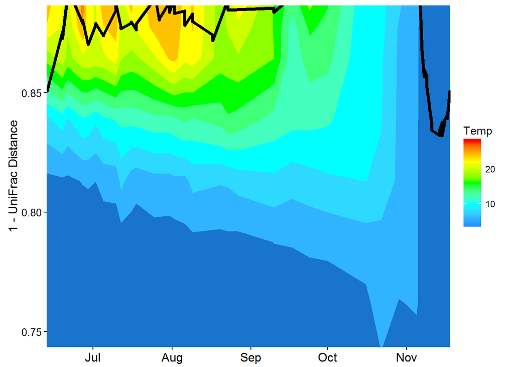

My interpretation of this figure was that the community of the Trout Bog hypolimnion was becoming more similar to the community of the Mary Lake hypolimnion over each season, but was interrupted by fall mixing every year. I proposed TEA depletion as a mechanism for this trend, but since we don’t have enough knowledge to link TEA use to 16S for most of the observed OTUs, I could not prove this. This was a major weakness of the paper.

After the reviews, I wanted to look into this trend more in depth. Specifically, I wanted to know which OTUs were gained over time. I assumed that as the number of OTUs shared between Trout Bog and Mary Lake increased, their abundances would also increase.

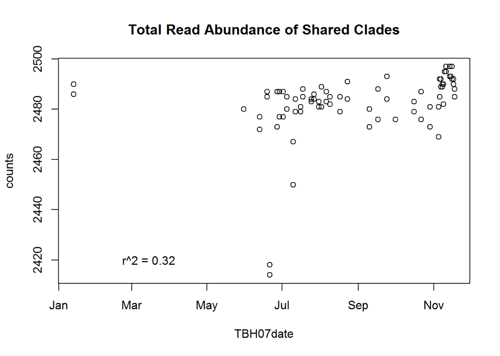

The plot above shows that the actual read abundance of shared taxa does not increase over time, even though the number of shared taxa does increase. I think the observed trend of increased similarity between these two locations is actually driven by biodiversity. Meromictic hypolimnia are more diverse than the other hypolimnia, so as Trout Bog gains new taxa over a season, there’s a high chance that those taxa are already present in Mary Lake. This is just another way of looking at the relationship between biodiversity and mixing. This may also be driving the observed trends in the connectivity analysis.

### So what now?

I’m not confident in presenting this figure as the main message of the paper. Instead, I’d like to expand the analysis to all seasonal trends and impacts of mixing, including general ones like biodiversity. I already started doing this to support part of another project based on our metagenomic data from Trout Bog, so many of the methods I’m using have already been developed.

The main message I’d like to get across is that epilimnia vary with seasonal factors, while hypolimnia vary with annual factors. The advantages of this approach are: - Allows use of the entire dataset, not just hypolimnion data - Incorporates and expands on the relationship of the hypolimnion community to mixing - Incorporates environmental metadata better (one of the main critques of the reviewers) - Is a more streamlined and approachable story

### Figure List, Take 2

Table 1. North Temperate Lakes - Microbial Observatory Study Sites. Lake locations, abbreviations, and physical and chemical characteristics (epilimnion/hypolimnion) are presented below. (I will make a nicer version of this in Word).

```
##                 Lakes IDs Depth SurfaceArea     Regime
## 1        Forestry Bog  FB   2.0        1300 Polymictic
## 2         Crystal Bog  CB   2.5        5600 Polymictic
## 3 North Sparkling Bog  NS   4.5        4700   Dimictic
## 4  West Sparkling Bog  WS   4.6       11900   Dimictic
## 5           Trout Bog  TB   7.0       10100   Dimictic
## 6 South Sparkling Bog  SS   8.0        4400   Dimictic
## 7      Hell's Kitchen  HK  19.3       30000 Meromictic
## 8           Mary Lake  MA  21.5       12000 Meromictic
##                     GPS                  Years        DIC         DOC
## 1 46.047776, -89.651248                   2007         NA          NA
## 2 46.007639, -89.606341       2005, 2007, 2009  0.69/1.72  15.47/13.6
## 3 46.004819, -89.705214       2007, 2008, 2009  1.12/2.31 10.05/10.40
## 4 46.004633, -89.709082                   2007         NA          NA
## 5 46.041140, -89.686352 2005, 2007, 2008, 2009  1.73/4.47 19.87/20.58
## 6 46.041140, -89.709082       2007, 2008, 2009  1.97/6.42 12.40/21.92
## 7 46.186674, -89.702510                   2007         NA          NA
## 8 46.250764, -89.900419 2005, 2007, 2008, 2009 5.54/12.38 20.63/67.10
##                TN           TP            TDN         TDP
## 1              NA           NA             NA          NA
## 2   620.57/846.00  30.00/38.86 1290.19/490.13 84.25/14.88
## 3   629.09/809.45 78.00/135.45  442.39/586.56 70.22/22.67
## 4              NA           NA             NA          NA
## 5  737.71/1121.00  50.57/53.25   582.5/820.21  34.5/31.57
## 6     813.88/1498  48.63/69.14 451.63/1179.21 16.25/18.29
## 7              NA           NA             NA          NA
## 8 1332.57/3652.38 78.00/303.50 1024.5/3220.14   71.13/228
```

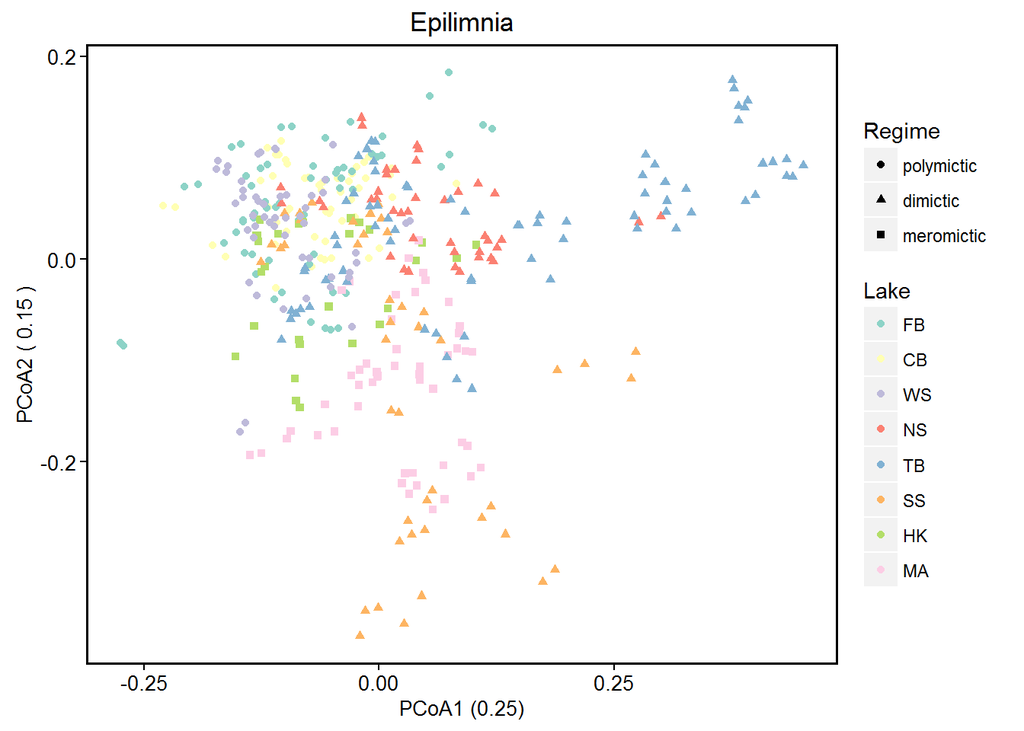

```
##
## Call:
## adonis(formula = x ~ Bog, data = as(sample_data(epi), "data.frame"))
##
## Permutation: free
## Number of permutations: 999
##
## Terms added sequentially (first to last)
##
##            Df SumsOfSqs MeanSqs F.Model      R2 Pr(>F)
## Bog         7     9.852  1.4074  31.768 0.36195  0.001 ***
## Residuals 392    17.367  0.0443         0.63805
## Total     399    27.219                 1.00000
## ---
## Signif. codes:  0 '***' 0.001 '**' 0.01 '*' 0.05 '.' 0.1 ' ' 1
```

```
##
## Call:
## adonis(formula = x ~ epi_regime, data = as(cbind(sample_data(epi),      epi_regime), "data.frame"))
##
## Permutation: free
## Number of permutations: 999
##
## Terms added sequentially (first to last)
##
##             Df SumsOfSqs MeanSqs F.Model      R2 Pr(>F)
## epi_regime   2    5.4747 2.73736  49.978 0.20114  0.001 ***
## Residuals  397   21.7444 0.05477         0.79886
## Total      399   27.2192                 1.00000
## ---
## Signif. codes:  0 '***' 0.001 '**' 0.01 '*' 0.05 '.' 0.1 ' ' 1
```

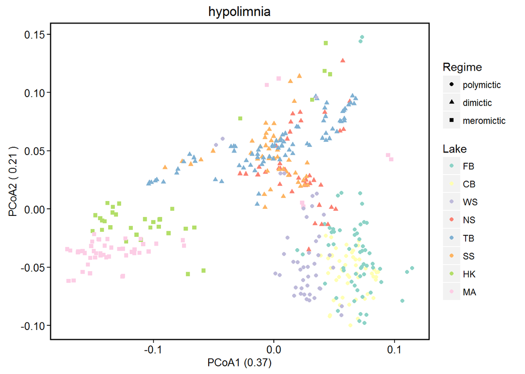

```
##
## Call:
## adonis(formula = x ~ Bog, data = as(sample_data(hypo), "data.frame"))
##
## Permutation: free
## Number of permutations: 999
##
## Terms added sequentially (first to last)
##
##            Df SumsOfSqs MeanSqs F.Model      R2 Pr(>F)
## Bog         7    3.0072 0.42960  66.011 0.53913  0.001 ***
## Residuals 395    2.5707 0.00651         0.46087
## Total     402    5.5778                 1.00000
## ---
## Signif. codes:  0 '***' 0.001 '**' 0.01 '*' 0.05 '.' 0.1 ' ' 1
```

```
##
## Call:
## adonis(formula = x ~ hypo_regime, data = as(cbind(sample_data(hypo),      hypo_regime), "data.frame"))
##
## Permutation: free
## Number of permutations: 999
##
## Terms added sequentially (first to last)
##
##              Df SumsOfSqs MeanSqs F.Model      R2 Pr(>F)
## hypo_regime   2    2.2333 1.11664  133.55 0.40038  0.001 ***
## Residuals   400    3.3446 0.00836         0.59962
## Total       402    5.5778                 1.00000
## ---
## Signif. codes:  0 '***' 0.001 '**' 0.01 '*' 0.05 '.' 0.1 ' ' 1
```

Figure 1. Community differences by lake and mixing regime. Principle coordinates analysis was performed on epilimnion and hypolimnion samples using a weighted UniFrac distance matrix. A permutational MANOVA test was used to determine significant clustering by lake and mixing regime. Significant clustering by both characteristics was found in both layers; however, correlation coefficients were higher in hypolimnia than in epilimnia. *This suggests that epilimnion communities are more similar between lakes than hypolimnion communities.*

Table 2. Indicator Taxa by layer and mixing regime. Indicator analysis was run on datasets separate by layer, with mixing dates removed, on taxa grouped by OTU, clade, and lineage. Differences between lakes indicate potential differences in biogeochemical cycling; for example, indicator taxa from Desulfobulbaceae, Desulfobacterales, and Syntrophobacterales suggest that sulfide reduction is taking place in dimictic and meromictic hypolimnia, but not in polymictic hypolimnia. Similar taxa are observed between epilimnia and hypolimnia from the same mixing regimes, suggesting interaction between the two layers. *Differences in layers and mixing regimes are reflected in the habitat preferences of bacterial taxa.*

```
##                                                                                                                   poly_epi_indicators
## 1                                                 k__Bacteria;p__Actinobacteria;c__Actinobacteria;o__Actinomycetales;acI;acI-B;acI-B3
## 2  k__Bacteria;p__Verrucomicrobia;c__[Spartobacteria];o__[Chthoniobacterales];f__[Chthoniobacteraceae];g__CandidatusXiphinematobacter
## 3                                                  k__Bacteria;p__Proteobacteria;c__Betaproteobacteria;o__Burkholderiales;betI;betI-A
## 4                                                              k__Bacteria;p__Actinobacteria;c__Actinobacteria;o__Actinomycetales;acI
## 5                                          k__Bacteria;p__Proteobacteria;c__Betaproteobacteria;o__Burkholderiales;betI;betI-A;Lhab-A1
## 6                                    k__Bacteria;p__Proteobacteria;c__Betaproteobacteria;o__Burkholderiales;betIII;betIII-A;betIII-A1
## 7                                                        k__Bacteria;p__Bacteroidetes;c__[Saprospirae];o__[Saprospirales];bacI;bacI-A
## 8                                                k__Bacteria;p__Bacteroidetes;c__[Saprospirae];o__[Saprospirales];bacI;bacI-A;bacI-A3
## 9                                             k__Bacteria;p__Proteobacteria;c__Alphaproteobacteria;o__Rhizobiales;alfI;alfI-A;alfI-A1
## 10
##                                                                                di_epi_indicators
## 1            k__Bacteria;p__Actinobacteria;c__Actinobacteria;o__Actinomycetales;acI;acI-B;acI-B2
## 2                  k__Bacteria;p__Actinobacteria;c__Acidimicrobiia;o__Acidimicrobiales;acV;acV-A
## 3                        k__Bacteria;p__Actinobacteria;c__Acidimicrobiia;o__Acidimicrobiales;acV
```

[output cut: 18 more lines]

```
##                                                                                                                  poly_hypo_indicators
## 1                                                              k__Bacteria;p__Actinobacteria;c__Actinobacteria;o__Actinomycetales;acI
## 2                                                  k__Bacteria;p__Proteobacteria;c__Betaproteobacteria;o__Burkholderiales;betI;betI-A
## 3                                                            k__Bacteria;p__Proteobacteria;c__Alphaproteobacteria;o__Rhizobiales;alfI
## 4  k__Bacteria;p__Verrucomicrobia;c__[Spartobacteria];o__[Chthoniobacterales];f__[Chthoniobacteraceae];g__CandidatusXiphinematobacter
## 5                                                        k__Bacteria;p__Proteobacteria;c__Betaproteobacteria;o__Methylophilales;betIV
## 6                                                        k__Bacteria;p__Bacteroidetes;c__[Saprospirae];o__[Saprospirales];bacI;bacI-A
## 7                                           k__Bacteria;p__Proteobacteria;c__Alphaproteobacteria;o__Rhizobiales;alfI;alfI-B;alfI-B1.1
## 8                                                               k__Bacteria;p__Bacteroidetes;c__[Saprospirae];o__[Saprospirales];bacI
## 9                                                          k__Bacteria;p__Proteobacteria;c__Alphaproteobacteria;o__Rhizobiales;alfI-A
## 10                                                        k__Bacteria;p__Proteobacteria;c__Betaproteobacteria;o__Burkholderiales;betI
##                                                                                                di_hypo_indicators
## 1                                     k__Bacteria;p__Acidobacteria;c__Holophagae;o__Holophagales;f__Holophagaceae
## 2  k__Bacteria;p__Proteobacteria;c__Deltaproteobacteria;o__Desulfobacterales;f__Desulfobulbaceae;g__Desulfobulbus
## 3                      k__Bacteria;p__Proteobacteria;c__Betaproteobacteria;o__Methylophilales;f__Methylophilaceae
```

[output cut: 18 more lines]

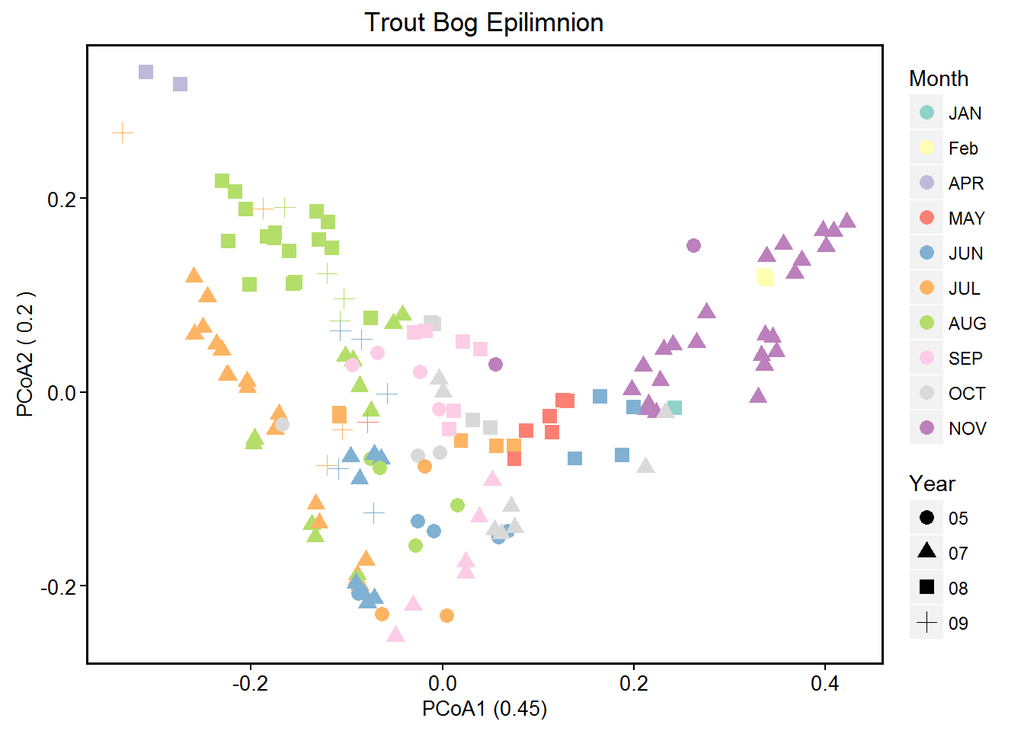

```
##
## Call:
## adonis(formula = x ~ Year, data = as(sample_data(TBE), "data.frame"))
##
## Permutation: free
## Number of permutations: 999
##
## Terms added sequentially (first to last)
##
##            Df SumsOfSqs MeanSqs F.Model      R2 Pr(>F)
## Year        3    1.4208  0.4736  7.4114 0.12761  0.001 ***
## Residuals 152    9.7130  0.0639         0.87239
## Total     155   11.1338                 1.00000
## ---
## Signif. codes:  0 '***' 0.001 '**' 0.01 '*' 0.05 '.' 0.1 ' ' 1
```

```
##
## Call:
## adonis(formula = x ~ TBEmonth, data = as(cbind(sample_data(TBE),      TBEmonth), "data.frame"))
##
## Permutation: free
## Number of permutations: 999
##
## Terms added sequentially (first to last)
##
##            Df SumsOfSqs MeanSqs F.Model      R2 Pr(>F)
## TBEmonth    9    5.8183 0.64648  17.757 0.52258  0.001 ***
## Residuals 146    5.3154 0.03641         0.47742
## Total     155   11.1338                 1.00000
## ---
## Signif. codes:  0 '***' 0.001 '**' 0.01 '*' 0.05 '.' 0.1 ' ' 1
```

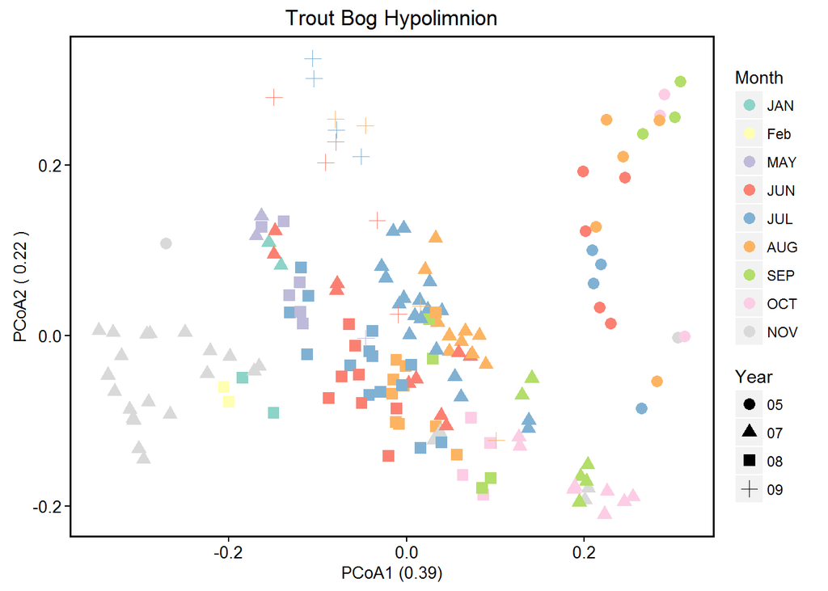

```
##
## Call:
## adonis(formula = x ~ Year, data = as(sample_data(TBH), "data.frame"))
##
## Permutation: free
## Number of permutations: 999
##
## Terms added sequentially (first to last)
##
##            Df SumsOfSqs MeanSqs F.Model      R2 Pr(>F)
## Year        3    3.7330 1.24432  27.031 0.33359  0.001 ***
## Residuals 162    7.4574 0.04603         0.66641
## Total     165   11.1903                 1.00000
## ---
## Signif. codes:  0 '***' 0.001 '**' 0.01 '*' 0.05 '.' 0.1 ' ' 1
```

```
##
## Call:
## adonis(formula = x ~ TBHmonth, data = as(cbind(sample_data(TBH),      TBHmonth), "data.frame"))
##
## Permutation: free
## Number of permutations: 999
##
## Terms added sequentially (first to last)
##
##            Df SumsOfSqs MeanSqs F.Model      R2 Pr(>F)
## TBHmonth    8    3.9185 0.48981  10.575 0.35017  0.001 ***
## Residuals 157    7.2719 0.04632         0.64983
## Total     165   11.1903                 1.00000
## ---
## Signif. codes:  0 '***' 0.001 '**' 0.01 '*' 0.05 '.' 0.1 ' ' 1
```

Figure 2. PCoA of the Trout Bog epilimnion and hypolimnion. This analysis shows which samples are most similar to each other. In the epilimnion, month is a strong predictor of sample similarity, regardless of year. Year is a much stronger determinant in the hypolimnion. In both layers, samples taken after the fall mixing event (late November, January and February samples) are most similar, regardless of year.

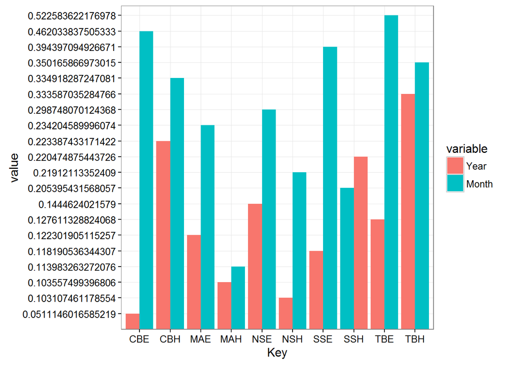

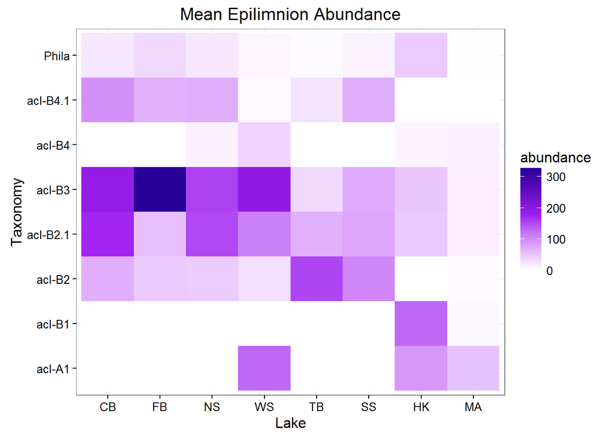

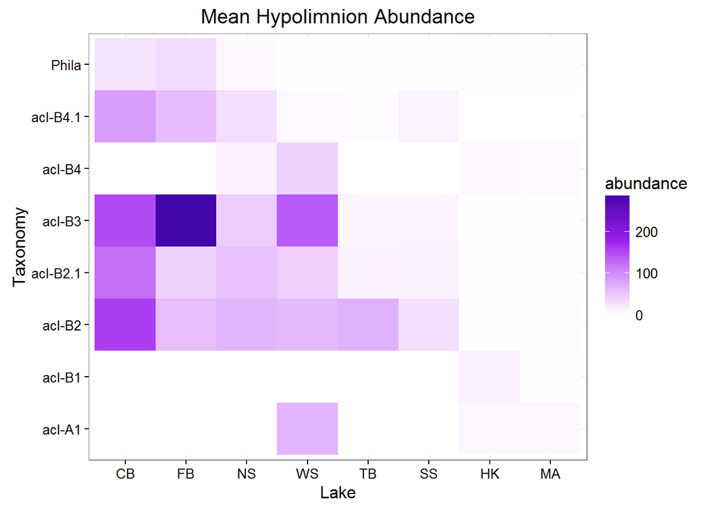

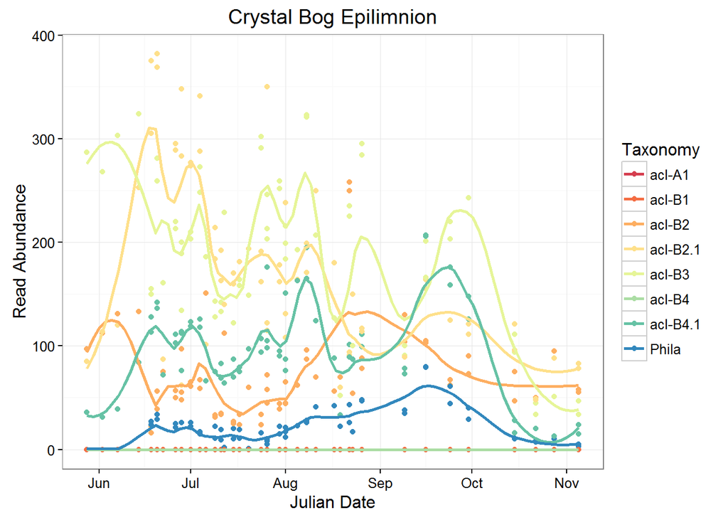

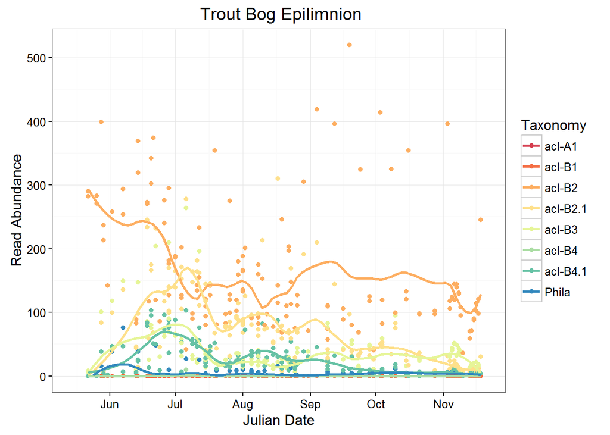

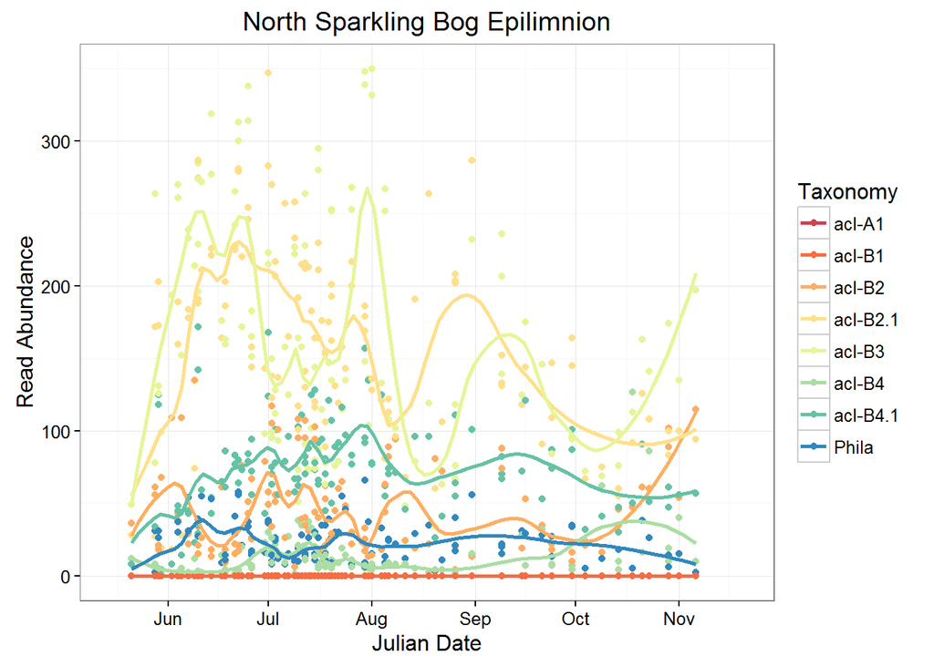

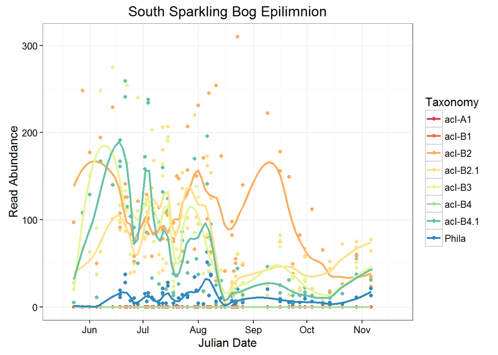

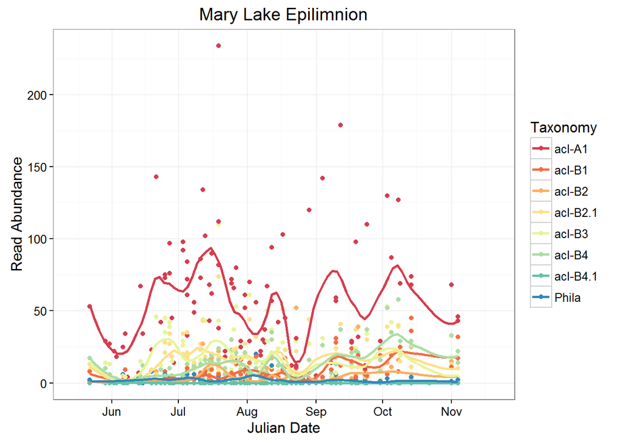

Figure 5. acI tribes by lake epilimnia, with trends representated by a smoothed conditional loess mean. In most lakes, acI-B OTUs of the same tribe (often B2) are anti-correlated, suggesting competition. acI-B OTUs of different tribes (B2, B3, and B4) often show similar trends. In Mary Lake, acI-A dominates instead of acI-B, suggesting sufficiently different environmental conditions to favor acI-A over acI-B.